# Wine Quality Data Analysis

Temitayo Ilori

02 April, 2019

```
## 'data.frame':    1599 obs. of  12 variables:
##  $ fixed.acidity       : num  7.4 7.8 7.8 11.2 7.4 7.4 7.9 7.3 7.8 7.5 ...
##  $ volatile.acidity    : num  0.7 0.88 0.76 0.28 0.7 0.66 0.6 0.65 0.58 0.5 ...
##  $ citric.acid         : num  0 0 0.04 0.56 0 0 0.06 0 0.02 0.36 ...
##  $ residual.sugar      : num  1.9 2.6 2.3 1.9 1.9 1.8 1.6 1.2 2 6.1 ...
##  $ chlorides           : num  0.076 0.098 0.092 0.075 0.076 0.075 0.069 0.065 0.073 0.071 ...
##  $ free.sulfur.dioxide : num  11 25 15 17 11 13 15 15 9 17 ...
##  $ total.sulfur.dioxide: num  34 67 54 60 34 40 59 21 18 102 ...
##  $ density             : num  0.998 0.997 0.997 0.998 0.998 ...
##  $ pH                  : num  3.51 3.2 3.26 3.16 3.51 3.51 3.3 3.39 3.36 3.35 ...
##  $ sulphates           : num  0.56 0.68 0.65 0.58 0.56 0.56 0.46 0.47 0.57 0.8 ...
##  $ alcohol             : num  9.4 9.8 9.8 9.8 9.4 9.4 9.4 10 9.5 10.5 ...
##  $ quality             : int  5 5 5 6 5 5 5 7 7 5 ...
```

```
##  [1] "fixed.acidity"        "volatile.acidity"     "citric.acid"
##  [4] "residual.sugar"       "chlorides"            "free.sulfur.dioxide"
##  [7] "total.sulfur.dioxide" "density"              "pH"
## [10] "sulphates"            "alcohol"              "quality"
```

```
##                      vars    n  mean    sd median trimmed   mad  min
## fixed.acidity           1 1599  8.32  1.74   7.90    8.15  1.48 4.60
## volatile.acidity        2 1599  0.53  0.18   0.52    0.52  0.18 0.12
## citric.acid             3 1599  0.27  0.19   0.26    0.26  0.25 0.00
## residual.sugar          4 1599  2.54  1.41   2.20    2.26  0.44 0.90
## chlorides               5 1599  0.09  0.05   0.08    0.08  0.01 0.01
## free.sulfur.dioxide     6 1599 15.87 10.46  14.00   14.58 10.38 1.00
## total.sulfur.dioxide    7 1599 46.47 32.90  38.00   41.84 26.69 6.00
## density                 8 1599  1.00  0.00   1.00    1.00  0.00 0.99
## pH                      9 1599  3.31  0.15   3.31    3.31  0.15 2.74
## sulphates              10 1599  0.66  0.17   0.62    0.64  0.12 0.33
## alcohol                11 1599 10.42  1.07  10.20   10.31  1.04 8.40
## quality                12 1599  5.64  0.81   6.00    5.59  1.48 3.00
##                         max  range skew kurtosis   se
## fixed.acidity         15.90  11.30 0.98     1.12 0.04
## volatile.acidity       1.58   1.46 0.67     1.21 0.00
## citric.acid            1.00   1.00 0.32    -0.79 0.00
## residual.sugar        15.50  14.60 4.53    28.49 0.04
## chlorides              0.61   0.60 5.67    41.53 0.00
## free.sulfur.dioxide   72.00  71.00 1.25     2.01 0.26
## total.sulfur.dioxide 289.00 283.00 1.51     3.79 0.82
## density                1.00   0.01 0.07     0.92 0.00
## pH                     4.01   1.27 0.19     0.80 0.00
## sulphates              2.00   1.67 2.42    11.66 0.00
## alcohol               14.90   6.50 0.86     0.19 0.03
## quality                8.00   5.00 0.22     0.29 0.02
```

```
##  fixed.acidity   volatile.acidity  citric.acid    residual.sugar
##  Min.   : 4.60   Min.   :0.1200   Min.   :0.000   Min.   : 0.900
##  1st Qu.: 7.10   1st Qu.:0.3900   1st Qu.:0.090   1st Qu.: 1.900
##  Median : 7.90   Median :0.5200   Median :0.260   Median : 2.200
##  Mean   : 8.32   Mean   :0.5278   Mean   :0.271   Mean   : 2.539
##  3rd Qu.: 9.20   3rd Qu.:0.6400   3rd Qu.:0.420   3rd Qu.: 2.600
##  Max.   :15.90   Max.   :1.5800   Max.   :1.000   Max.   :15.500
##    chlorides       free.sulfur.dioxide total.sulfur.dioxide
##  Min.   :0.01200   Min.   : 1.00       Min.   :  6.00
##  1st Qu.:0.07000   1st Qu.: 7.00       1st Qu.: 22.00
##  Median :0.07900   Median :14.00       Median : 38.00
##  Mean   :0.08747   Mean   :15.87       Mean   : 46.47
##  3rd Qu.:0.09000   3rd Qu.:21.00       3rd Qu.: 62.00
##  Max.   :0.61100   Max.   :72.00       Max.   :289.00
##     density             pH          sulphates         alcohol
##  Min.   :0.9901   Min.   :2.740   Min.   :0.3300   Min.   : 8.40
##  1st Qu.:0.9956   1st Qu.:3.210   1st Qu.:0.5500   1st Qu.: 9.50
##  Median :0.9968   Median :3.310   Median :0.6200   Median :10.20
##  Mean   :0.9967   Mean   :3.311   Mean   :0.6581   Mean   :10.42
##  3rd Qu.:0.9978   3rd Qu.:3.400   3rd Qu.:0.7300   3rd Qu.:11.10
##  Max.   :1.0037   Max.   :4.010   Max.   :2.0000   Max.   :14.90
##     quality
##  Min.   :3.000
##  1st Qu.:5.000
##  Median :6.000
##  Mean   :5.636
##  3rd Qu.:6.000
##  Max.   :8.000
```

# Univariate Plots Section

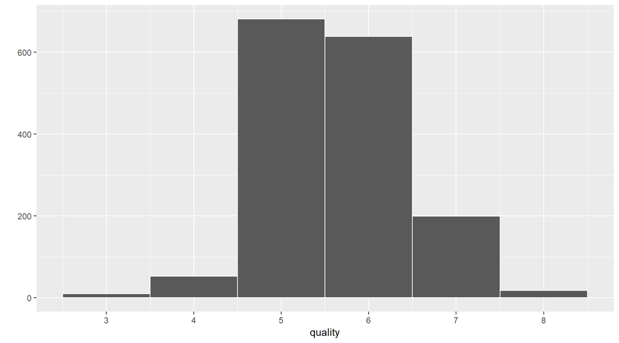

I chose to use histogram because I wanted to see the distributions of Quality and to graphically summarize it. Quality seems to be normally distributed.

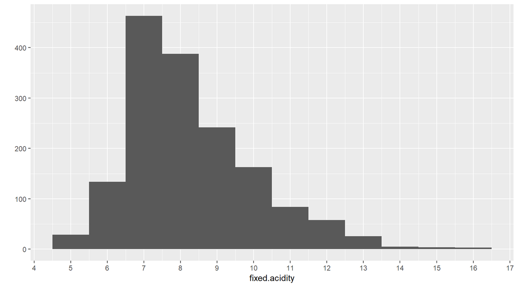

I chose to use histogram because I wanted to see the distributions of fixed acidity and to graphically summarize it. The distribution is positively skewed.

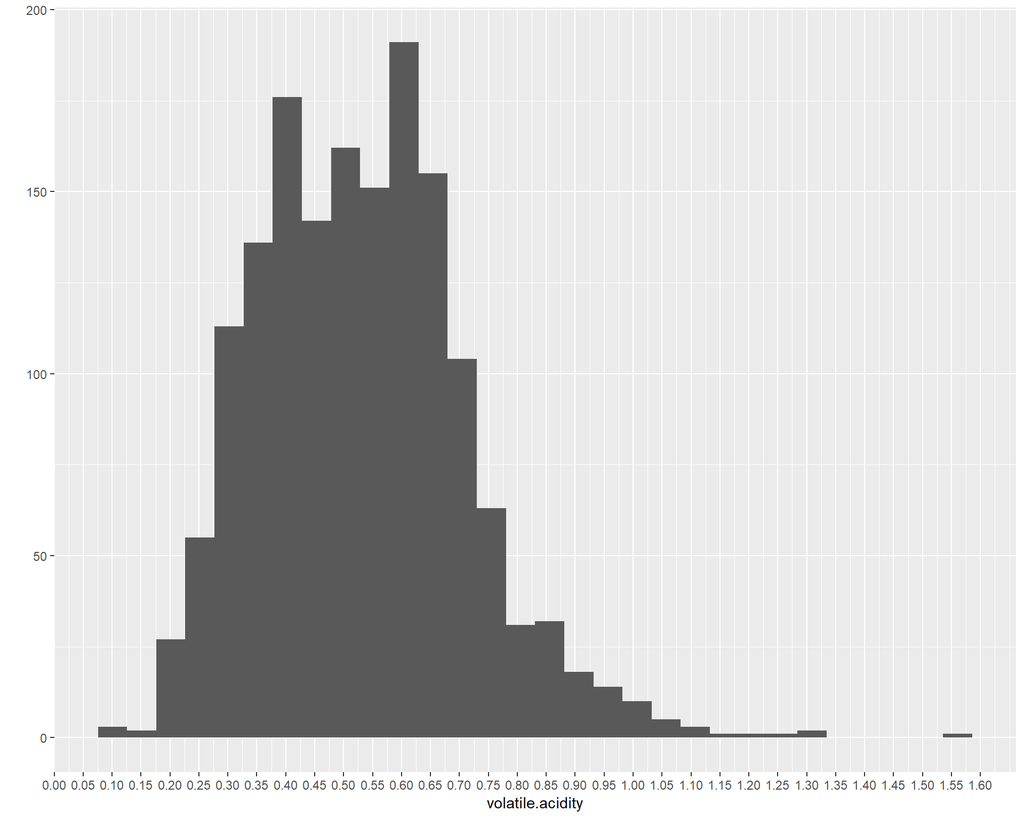

I chose to use histogram because I wanted to see the distributions of volatile acidity and to graphically summarize it. The distribution seems bimodal.

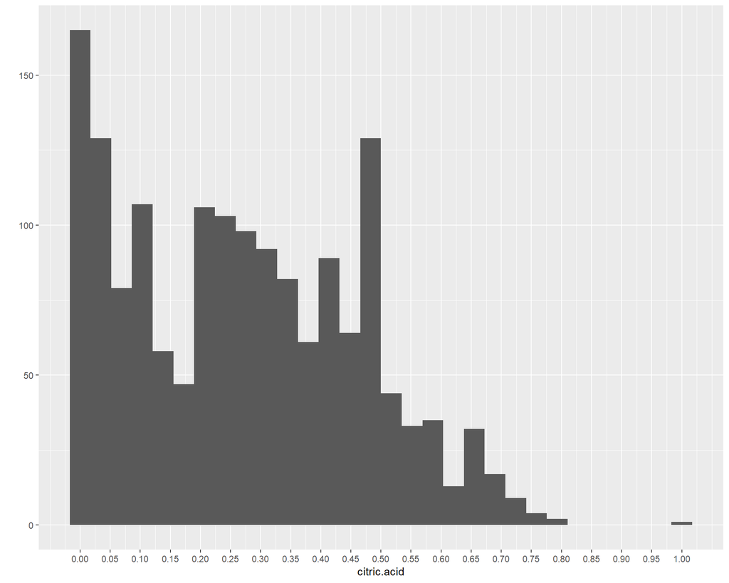

I chose to use histogram because I wanted to see the distributions of citric acid and to graphically summarize it. The distribution seems bimodal.

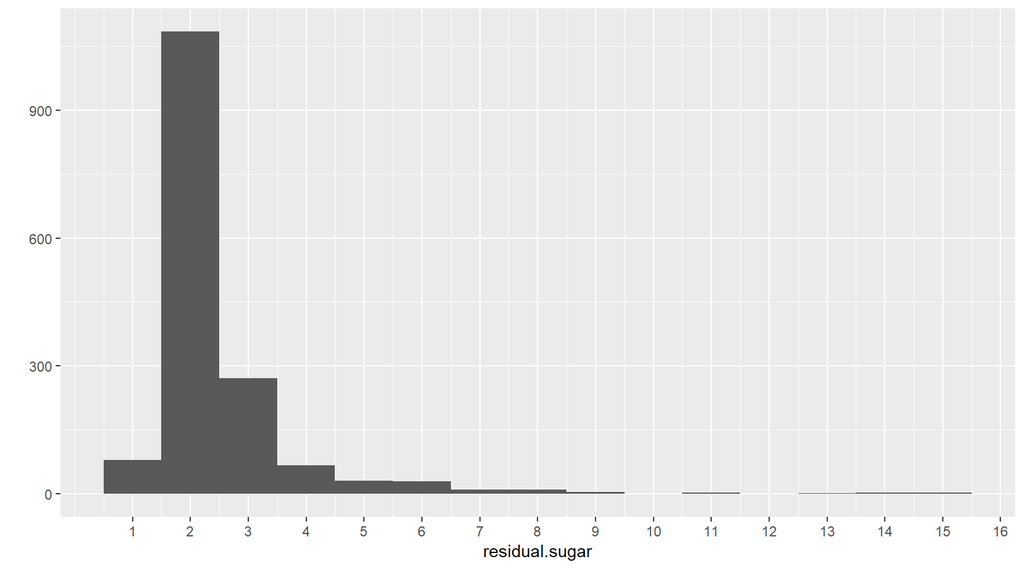

I chose to use histogram because I wanted to see the distributions of residual sugar and to graphically summarize it. Residual sugar is positively skewed with a few outliers.

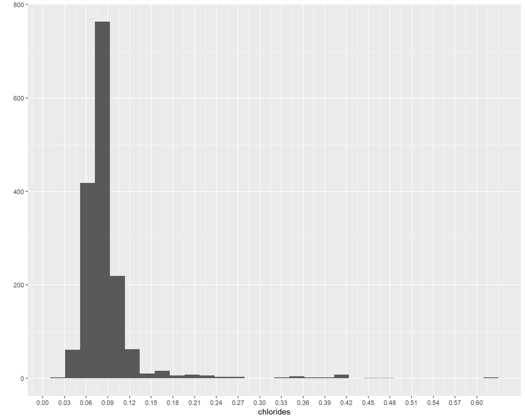

I chose to use histogram because I wanted to see the distributions of chlride and to graphically summarize it. Chlorides is positively skewed with a couple of outliers.

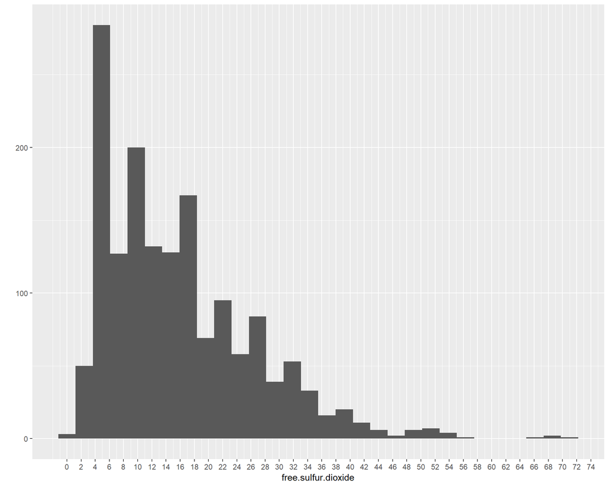

I chose to use histogram because I wanted to see the distributions of free sulphure dioxide and to graphically summarize it. The distribution is positively skewed.

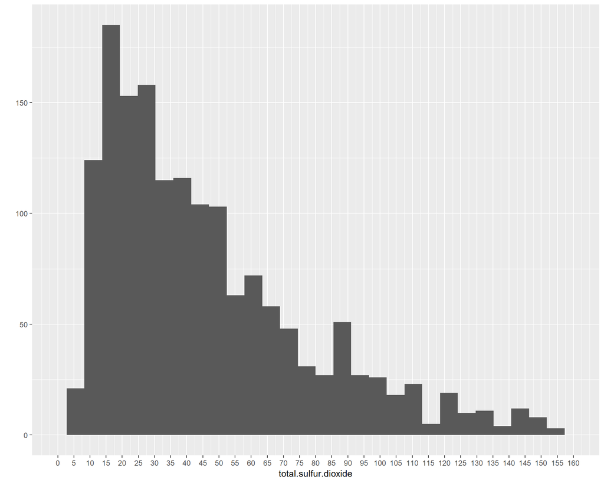

I chose to use histogram because I wanted to see the distributions of total sulphur dioxide and to graphically summarize it. The distribution is positively skewed.

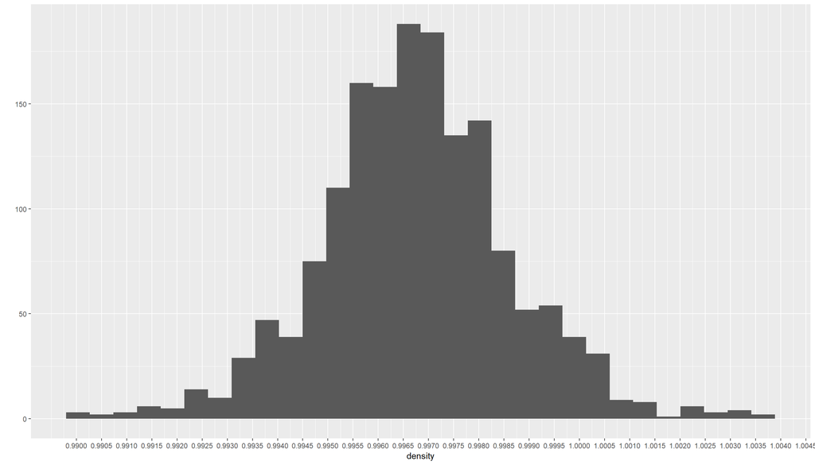

I chose to use histogram because I wanted to see the distributions of Density and to graphically summarize it. Density is normally distributed

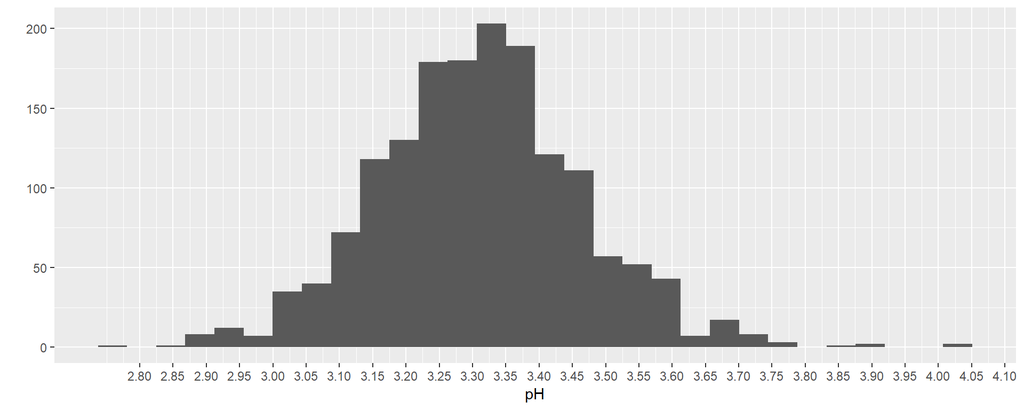

[output not shown]

I chose to use histogram because I wanted to see the distributions of pH and to graphically summarize it. pH is normaly distributed.

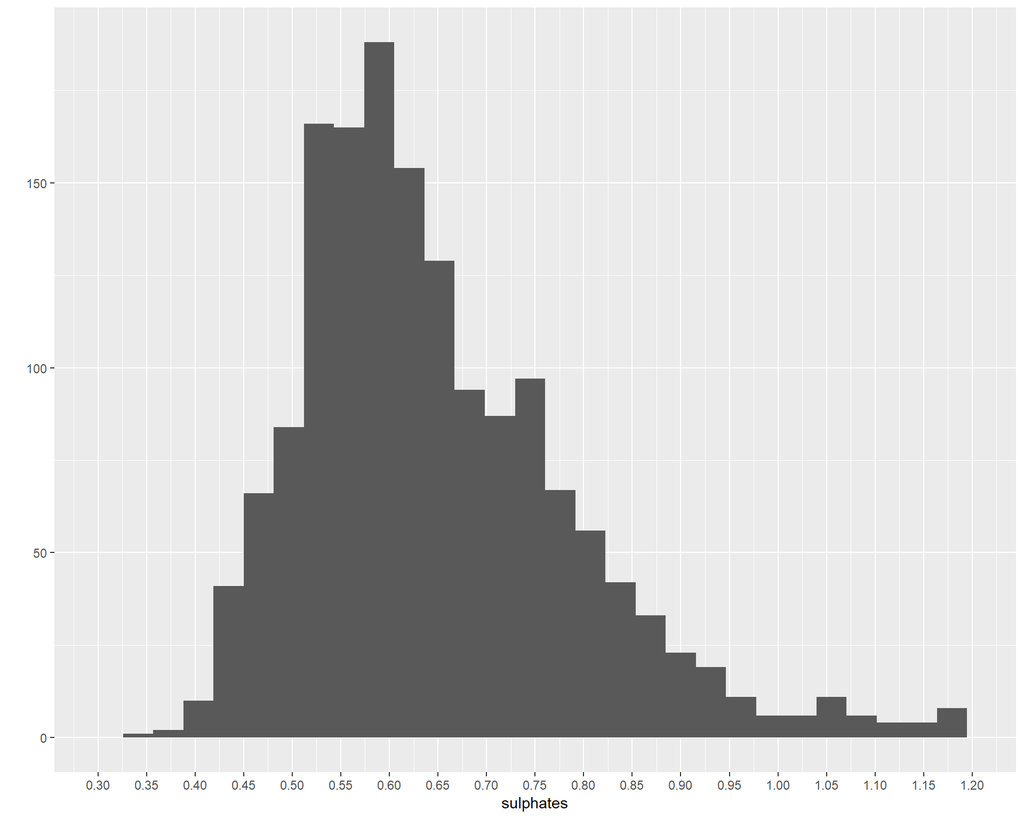

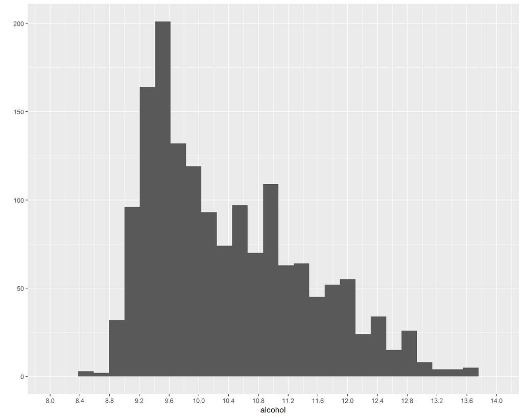

I chose to use histogram because I wanted to see the distributions of alcohol and to graphically summarize it. Alcohol is positively skewed.

# Univariate Analysis

### What is the structure of your dataset?

There are 1599 observations in the dataset with 12 variables (fixed.acidity, volatile.acidity, citric.acid, residual.sugar, chlorides, free.sulfur.dioxide, total.sulfur.dioxide, density, pH, sulphates, alcohol and quality).

### What is/are the main feature(s) of interest in your dataset?

The main feature of my dataset is Quality. I would like to know what factors can be used to predict wine quality.

### What other features in the dataset do you think will help support your into your feature(s) of interest?

Alcohol, PH, density, fixed acidity and citric acid.

### Did you create any new variables from existing variables in the dataset?

No.

### Of the features you investigated, were there any unusual distributions? you perform any operations on the data to tidy, adjust, or change the form the data? If so, why did you do this?

# Bivariate Plots Section

```
##                        fixed\nacidity volatile\nacidity citric\nacid
## fixed\nacidity                   1.00             -0.26         0.67
## volatile\nacidity               -0.26              1.00        -0.55
## citric\nacid                     0.67             -0.55         1.00
## residual\nsugar                  0.11              0.00         0.14
## chlorides                        0.09              0.06         0.20
## free\nsulfur\ndioxide           -0.15             -0.01        -0.06
## total\nsulfur\ndioxide          -0.11              0.08         0.04
## density                          0.67              0.02         0.36
## pH                              -0.68              0.23        -0.54
## sulphates                        0.18             -0.26         0.31
## alcohol                         -0.06             -0.20         0.11
## quality                          0.12             -0.39         0.23
##                        residual\nsugar chlorides free\nsulfur\ndioxide
## fixed\nacidity                    0.11      0.09                 -0.15
## volatile\nacidity                 0.00      0.06                 -0.01
## citric\nacid                      0.14      0.20                 -0.06
## residual\nsugar                   1.00      0.06                  0.19
## chlorides                         0.06      1.00                  0.01
## free\nsulfur\ndioxide             0.19      0.01                  1.00
## total\nsulfur\ndioxide            0.20      0.05                  0.67
## density                           0.36      0.20                 -0.02
## pH                               -0.09     -0.27                  0.07
## sulphates                         0.01      0.37                  0.05
## alcohol                           0.04     -0.22                 -0.07
## quality                           0.01     -0.13                 -0.05
##                        total\nsulfur\ndioxide density    pH sulphates
## fixed\nacidity                          -0.11    0.67 -0.68      0.18
## volatile\nacidity                        0.08    0.02  0.23     -0.26
## citric\nacid                             0.04    0.36 -0.54      0.31
## residual\nsugar                          0.20    0.36 -0.09      0.01
## chlorides                                0.05    0.20 -0.27      0.37
## free\nsulfur\ndioxide                    0.67   -0.02  0.07      0.05
## total\nsulfur\ndioxide                   1.00    0.07 -0.07      0.04
## density                                  0.07    1.00 -0.34      0.15
## pH                                      -0.07   -0.34  1.00     -0.20
## sulphates                                0.04    0.15 -0.20      1.00
## alcohol                                 -0.21   -0.50  0.21      0.09
## quality                                 -0.19   -0.17 -0.06      0.25
##                        alcohol quality
## fixed\nacidity           -0.06    0.12
## volatile\nacidity        -0.20   -0.39
## citric\nacid              0.11    0.23
## residual\nsugar           0.04    0.01
## chlorides                -0.22   -0.13
## free\nsulfur\ndioxide    -0.07   -0.05
## total\nsulfur\ndioxide   -0.21   -0.19
## density                  -0.50   -0.17
## pH                        0.21   -0.06
## sulphates                 0.09    0.25
## alcohol                   1.00    0.48
## quality                   0.48    1.00
```

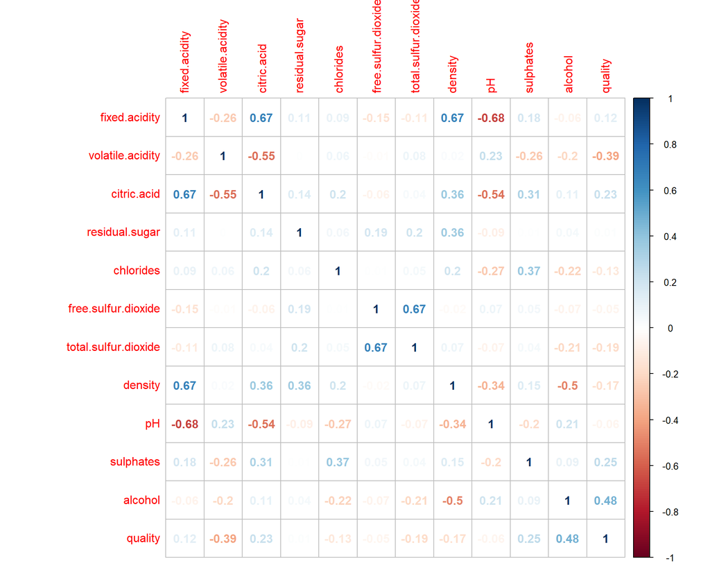

I chose correlation plot to show the correlation between each pair of wine characteristics.The highest correlation is between PH and fixed acidity (-0.68)

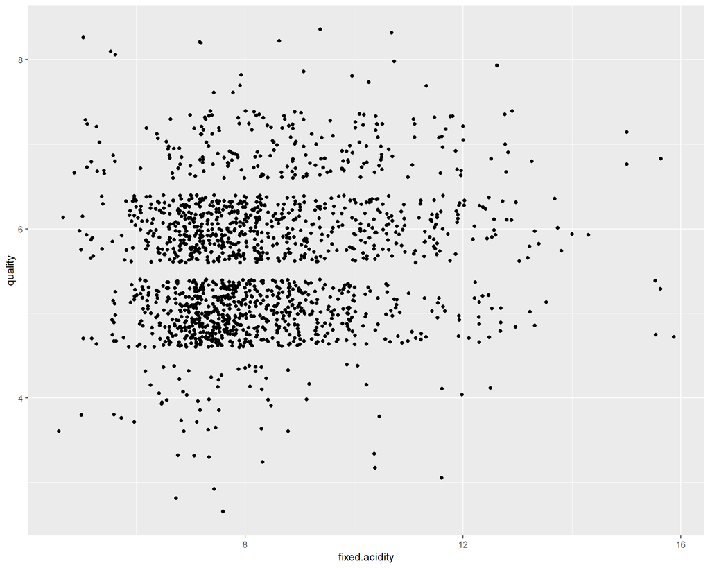

I chose scatter plot to show the relationship between quality and fixed acitity.There doesn’t seem to be a difined relationship between them.

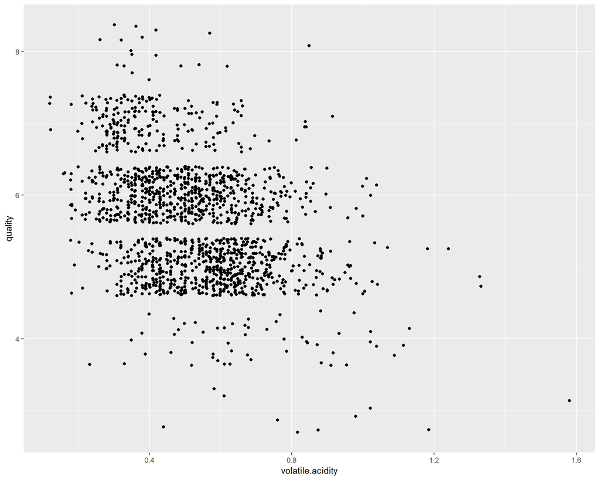

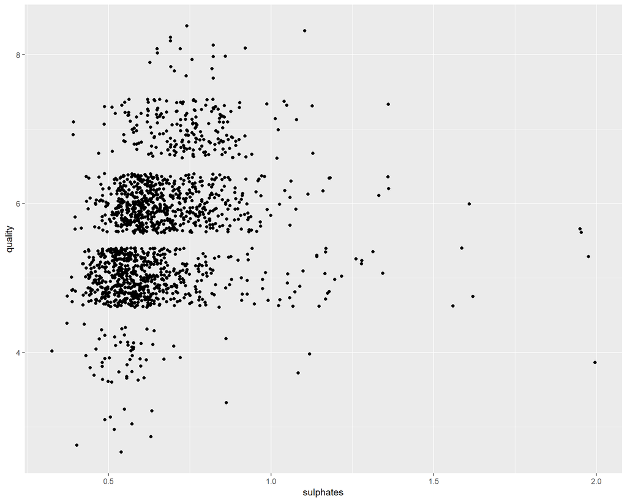

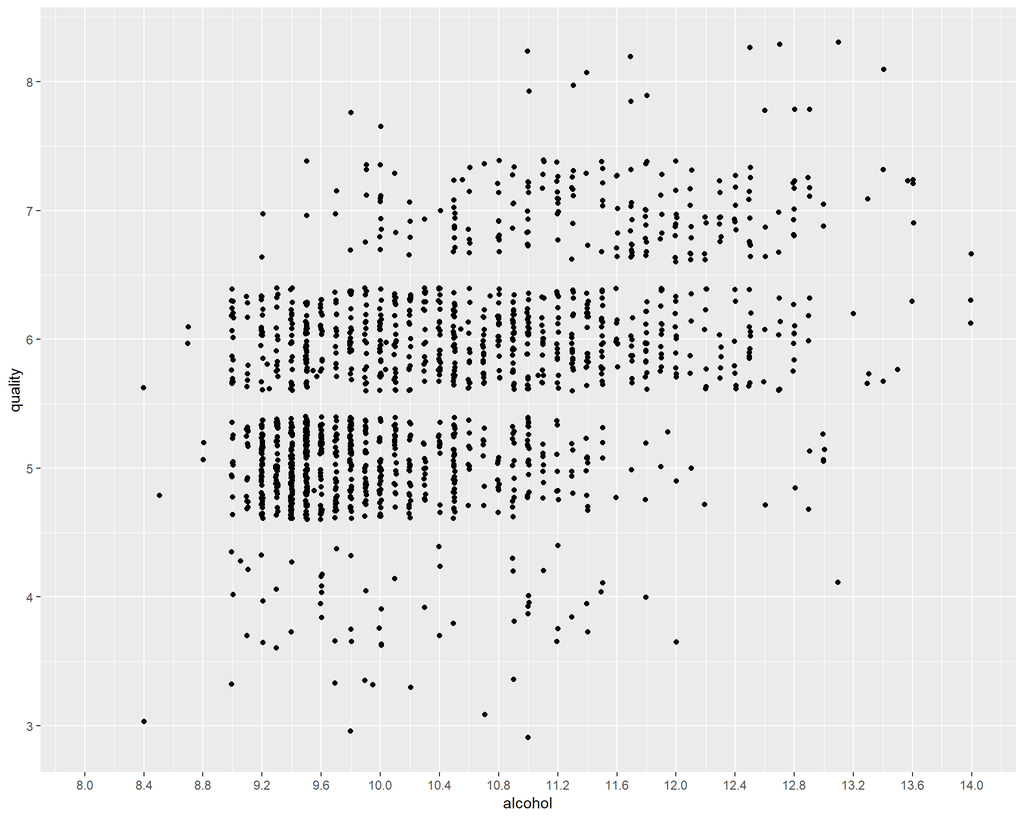

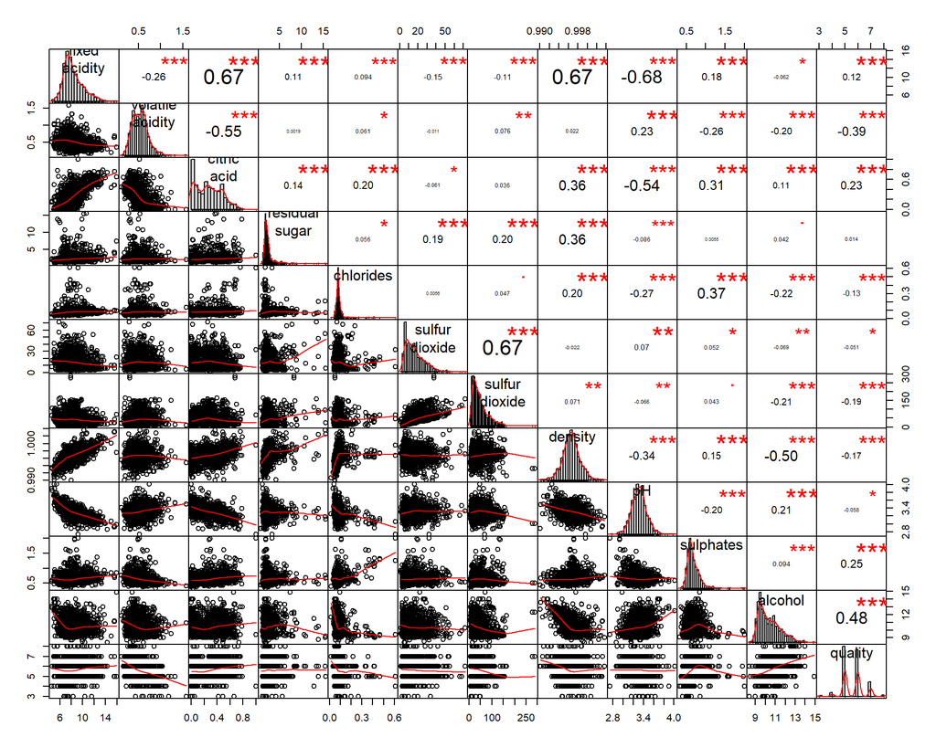

I chose correlation matrix because it shows both the correlation of each variable to each of the other variables as well as the relationship between them.

# Bivariate Analysis

### What was the strongest relationship you found?

The strongest relationship found is a negative correlation of -0.68 between PH and fixed acidity.

# Multivariate Plots Section

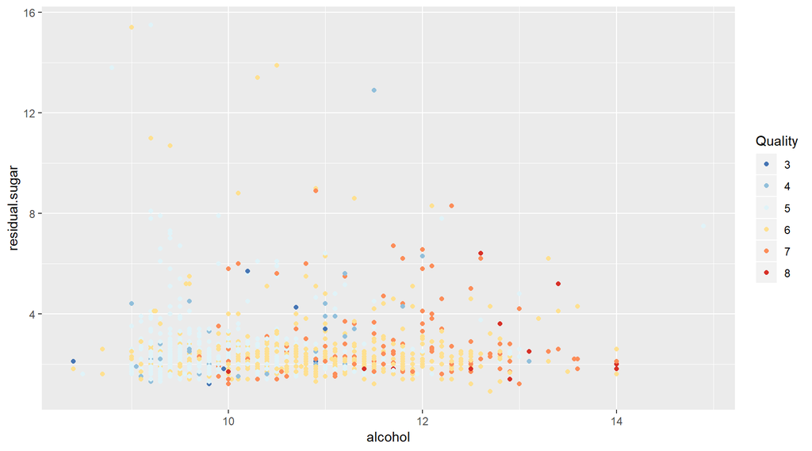

I chose scatter plot to show the relationship between residual sugar, alcohol and quality. There doesn’t seem to be a defined relationship between the variables, except for lower quality wine that seem to fall to the left of the alcohol axis.

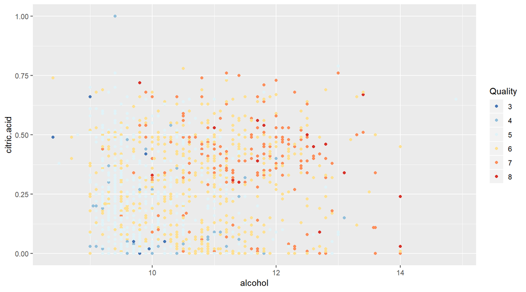

I chose scatter plot to show the relationship between citric acidity, alcohol and quality. Lower quality wine seem to fall to the left of the alcohol axis.

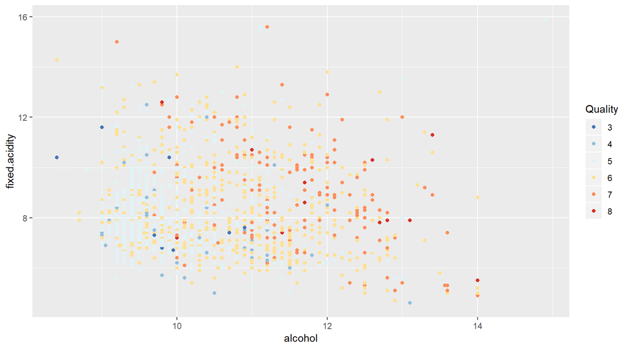

I chose scatter plot to show the relationship between fixed acidity, alcohol and quality.

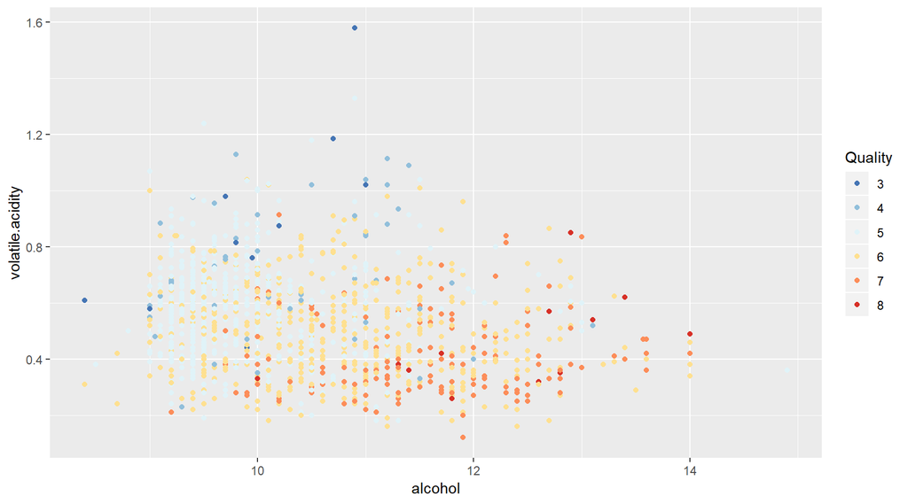

I chose scatter plot to show the relationship between volatile acidity, alcohol and quality.

```
##
## Call:
## lm(formula = quality ~ alcohol + sulphates + volatile.acidity,
##     data = wine_data)
##
## Residuals:
##     Min      1Q  Median      3Q     Max
## -2.7186 -0.3820 -0.0641  0.4746  2.1807
##
## Coefficients:
##                  Estimate Std. Error t value Pr(>|t|)
## (Intercept)       2.61083    0.19569  13.342  < 2e-16 ***
## alcohol           0.30922    0.01580  19.566  < 2e-16 ***
## sulphates         0.67903    0.10080   6.737 2.26e-11 ***
## volatile.acidity -1.22140    0.09701 -12.591  < 2e-16 ***
## ---
## Signif. codes:  0 '***' 0.001 '**' 0.01 '*' 0.05 '.' 0.1 ' ' 1
##
## Residual standard error: 0.6587 on 1595 degrees of freedom
## Multiple R-squared:  0.3359, Adjusted R-squared:  0.3346
## F-statistic: 268.9 on 3 and 1595 DF,  p-value: < 2.2e-16
```

I chose regression model in order to show the linear relationship between quality and alcohol, sulphates and volatile acidity. More explanation of the model is below.

I chose scatter plot because I needed to see the relationship between more than two variables. Two variables are on x and y axis and the third is ued as a color.

# Multivariate Analysis

### Talk about some of the relationships you observed in this part of the investigation. Were there features that strengthened each other in terms of at your feature(s) of interest?

I created a regression model that uses alcohol, sulphates and volcatile acidity as the predictor and quality as the response variable. I chose those predictors because they have the highest correlations with quality. The F-Statistict is 268.9 and the p-value < 2.2e-16, which means that at least one of the predictor variables is significantly related to Quality.

The p-value of each of the variables shows they are all significant in predicting Quality.Thus, the equation for predicting quality is Quality= 2.61083 + 0.30922alcohol + 0.67903sulphates -1.22140volatile.acidity

Adjusted R-squared: 0.3346. This means our model can only predict 33% of the variation in the Quality. This is a little low.

### Were there any interesting or surprising interactions between features?

I found that wine with lower alchohol level tend to have lower quality.

### OPTIONAL: Did you create any models with your dataset? Discuss the strengths and limitations of your model.

# Final Plots and Summary

### Plot one

[figure not shown]

### Plot Two

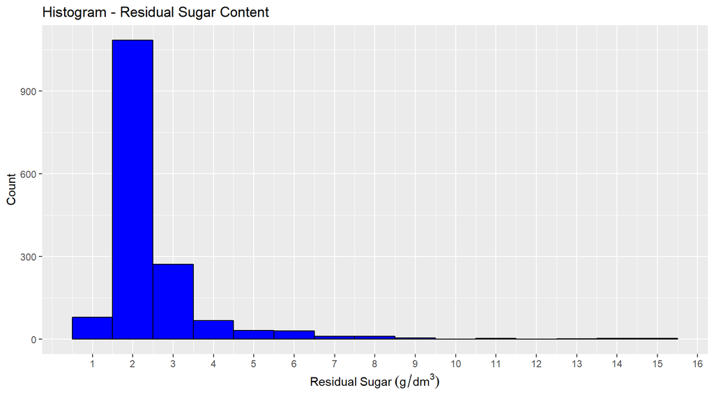

### Description Two

This chart has been enhanced by adding fill color (blue) and the line color (black). The title as well as the y axis label have been added.This chart is equally positively skewed. The median is 2 while the mean (2.54) is to the right.

### Plot three

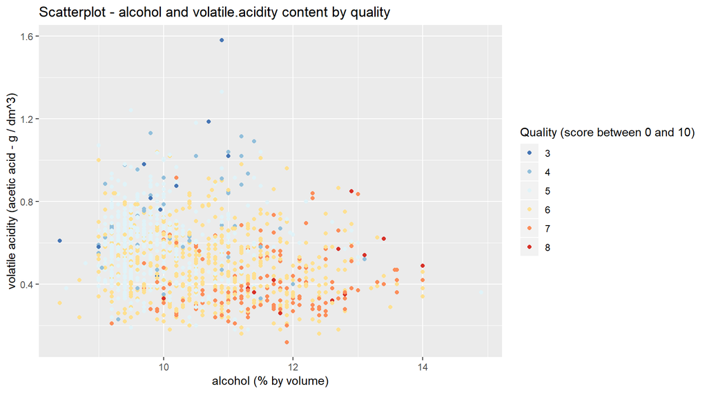

### Description three

This plot has been imporoved by adding the title. I also gave the Legend a more descriptive name. I added the unit of measurement to both x and y axis. Wine quality tends to increase as alcohol content increases and as volatile acidity redduces.

# Reflection

I was interested in which of the other variables could be used to predict the quality of wine. I plotted a correlation plot of each pair of the variables. Most of the correlations are so small. The highest was a correlation of -0.68 between pH and fixed acidity.

Most of the bivariate plot show no correlation. In the multivariate plots, however, it can be seen that lower quality wine tend to have lower alcohol content.

I did a regression analysis of quality against alcohol, sulphates and volatile acidity. All the variables, together, are significant in predicting the quality of wine.

It would have been nice to know how the Quality of wine is measured.